# Video Game Sales 电子游戏销售分析

仓库地址：https://github.com/lucien1998/DataMingLDY

# 一、数据预处理

```python
import pandas as pd
import numpy as np
import matplotlib.pyplot as plt
import matplotlib.style as style
import seaborn as sns
from sklearn.preprocessing import LabelEncoder
from sklearn.tree import DecisionTreeRegressor
from sklearn.metrics import mean_squared_error, r2_score
from sklearn.model_selection import train_test_split, GridSearchCV
```

### 读取数据

```python
df = pd.read_csv("vgsales.csv")
df.head()
```

|  | Rank | Name | Platform | Year | Genre | Publisher | NA_Sales | EU_Sales | JP_Sales | Other_Sales | Global_Sales |
| --- | --- | --- | --- | --- | --- | --- | --- | --- | --- | --- | --- |
| 0 | 1 | Wii Sports | Wii | 2006.0 | Sports | Nintendo | 41.49 | 29.02 | 3.77 | 8.46 | 82.74 |
| 1 | 2 | Super Mario Bros. | NES | 1985.0 | Platform | Nintendo | 29.08 | 3.58 | 6.81 | 0.77 | 40.24 |
| 2 | 3 | Mario Kart Wii | Wii | 2008.0 | Racing | Nintendo | 15.85 | 12.88 | 3.79 | 3.31 | 35.82 |
| 3 | 4 | Wii Sports Resort | Wii | 2009.0 | Sports | Nintendo | 15.75 | 11.01 | 3.28 | 2.96 | 33.00 |
| 4 | 5 | Pokemon Red/Pokemon Blue | GB | 1996.0 | Role-Playing | Nintendo | 11.27 | 8.89 | 10.22 | 1.00 | 31.37 |

```python
df.info()
```

```
<class 'pandas.core.frame.DataFrame'>
RangeIndex: 16598 entries, 0 to 16597
Data columns (total 11 columns):
 #   Column        Non-Null Count  Dtype
---  ------        --------------  -----
 0   Rank          16598 non-null  int64
 1   Name          16598 non-null  object
 2   Platform      16598 non-null  object
 3   Year          16327 non-null  float64
 4   Genre         16598 non-null  object
 5   Publisher     16540 non-null  object
 6   NA_Sales      16598 non-null  float64
 7   EU_Sales      16598 non-null  float64
 8   JP_Sales      16598 non-null  float64
 9   Other_Sales   16598 non-null  float64
 10  Global_Sales  16598 non-null  float64
dtypes: float64(6), int64(1), object(4)
memory usage: 1.4+ MB
```

由数据字段信息可知，Video Game Sales电子游戏销售数据集中包括11个属性。

### 缺失值处理

```python
df.isnull().sum()
```

```
Rank              0
Name              0
Platform          0
Year            271
Genre             0
Publisher        58
NA_Sales          0
EU_Sales          0
JP_Sales          0
Other_Sales       0
Global_Sales      0
dtype: int64
```

可以发现：Year和和Publisher两列存在缺失值。根据已有的方法们无法推断出Year和Publisher的值，故不采用数据填充的方法，而是直接删除缺失值。

```python
df.dropna(inplace=True)
df.isnull().sum()
```

```
Rank            0
Name            0
Platform        0
Year            0
Genre           0
Publisher       0
NA_Sales        0
EU_Sales        0
JP_Sales        0
Other_Sales     0
Global_Sales    0
dtype: int64
```

可以发现：处理后的数据不再有缺失值。此时可以查看数据属性的情况。

```python
df.describe()
```

|  | Rank | Year | NA_Sales | EU_Sales | JP_Sales | Other_Sales | Global_Sales |
| --- | --- | --- | --- | --- | --- | --- | --- |
| count | 16291.000000 | 16291.000000 | 16291.000000 | 16291.000000 | 16291.000000 | 16291.000000 | 16291.000000 |
| mean | 8290.190228 | 2006.405561 | 0.265647 | 0.147731 | 0.078833 | 0.048426 | 0.540910 |
| std | 4792.654450 | 5.832412 | 0.822432 | 0.509303 | 0.311879 | 0.190083 | 1.567345 |
| min | 1.000000 | 1980.000000 | 0.000000 | 0.000000 | 0.000000 | 0.000000 | 0.010000 |
| 25% | 4132.500000 | 2003.000000 | 0.000000 | 0.000000 | 0.000000 | 0.000000 | 0.060000 |
| 50% | 8292.000000 | 2007.000000 | 0.080000 | 0.020000 | 0.000000 | 0.010000 | 0.170000 |
| 75% | 12439.500000 | 2010.000000 | 0.240000 | 0.110000 | 0.040000 | 0.040000 | 0.480000 |
| max | 16600.000000 | 2020.000000 | 41.490000 | 29.020000 | 10.220000 | 10.570000 | 82.740000 |

# 二、电子游戏市场分析

电子游戏市场分析：受欢迎的游戏、类型、发布平台、发行人等；

## 1、受欢迎的游戏

```python
name_data = df[['Name','Global_Sales','Year','Genre']].sort_values(by='Global_Sales', ascending=False).head(10)
name_data
```

|  | Name | Global_Sales | Year | Genre |
| --- | --- | --- | --- | --- |
| 0 | Wii Sports | 82.74 | 2006.0 | Sports |
| 1 | Super Mario Bros. | 40.24 | 1985.0 | Platform |
| 2 | Mario Kart Wii | 35.82 | 2008.0 | Racing |
| 3 | Wii Sports Resort | 33.00 | 2009.0 | Sports |
| 4 | Pokemon Red/Pokemon Blue | 31.37 | 1996.0 | Role-Playing |
| 5 | Tetris | 30.26 | 1989.0 | Puzzle |
| 6 | New Super Mario Bros. | 30.01 | 2006.0 | Platform |
| 7 | Wii Play | 29.02 | 2006.0 | Misc |
| 8 | New Super Mario Bros. Wii | 28.62 | 2009.0 | Platform |
| 9 | Duck Hunt | 28.31 | 1984.0 | Shooter |

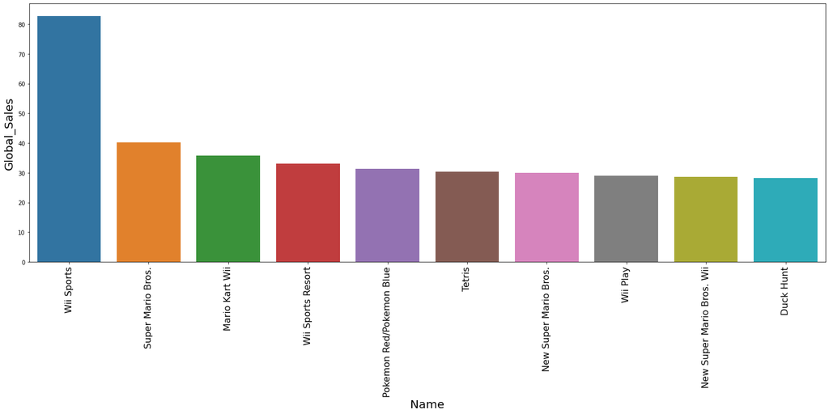

```python
plt.figure(figsize=(20, 10))
sns.barplot(y='Global_Sales',x='Name',data=name_data)
plt.xticks(plt.xticks()[0], rotation=90, size=16)
plt.tight_layout()
plt.xlabel('Name', fontsize = 20)
plt.ylabel('Global_Sales', fontsize = 20)
plt.show()
```

由图表可以看出，受欢迎的游戏前三名为：Wii Sports、Super Mario Bros、Mario Kart Wii，其中2006年发行的Wii Sports是最受欢迎的游戏。

## 2、受欢迎的游戏类型

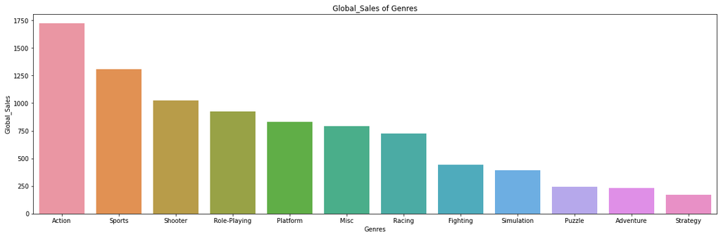

```python
genre_data = df.groupby(['Genre']).sum().loc[:,'Global_Sales'].sort_values(ascending=False)
plt.figure(figsize=(20, 6))
sns.barplot(y=genre_data.values, x=genre_data.index)
plt.xlabel('Genres')
plt.ylabel('Global_Sales')
plt.title('Global_Sales of Genres')
plt.show()
```

由图中可以看出，受欢迎的游戏类型前三名为：Action、Sports、Shooter，其中Action类型的游戏最受欢迎，而Strategy类型的游戏则相对小众。

## 3、受欢迎的游戏发布平台

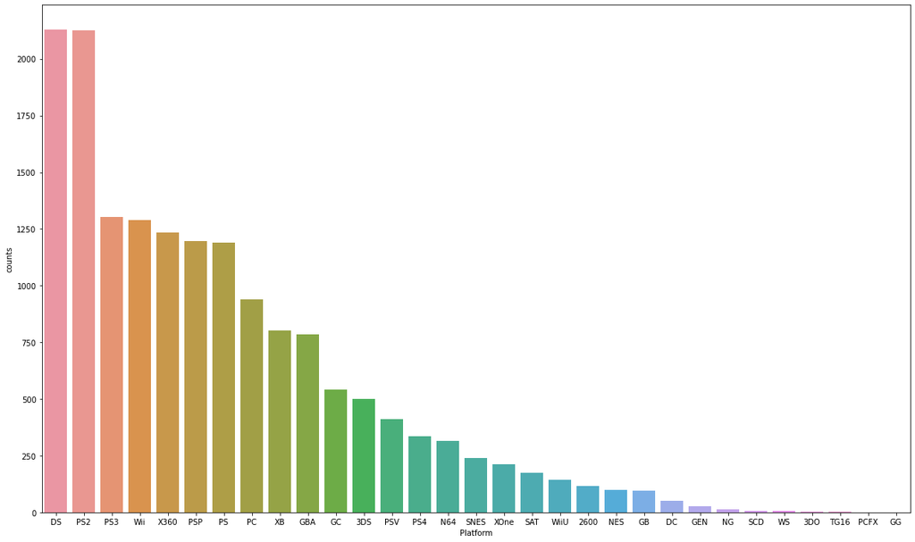

```python
platform_data = df.groupby(['Platform']).count().loc[:,'Name'].sort_values(ascending=False)
plt.figure(figsize=(20,12))
sns.barplot(y=platform_data.values, x=platform_data.index)
plt.xlabel('Platform')
plt.ylabel('counts')
plt.show()
```

由图中可以看出，最受欢迎的游戏发布平台为DS和PS2，而3DO，TG16、PCFX、GG等游戏发布平台几乎没落。

## 4、受欢迎的游戏发行人

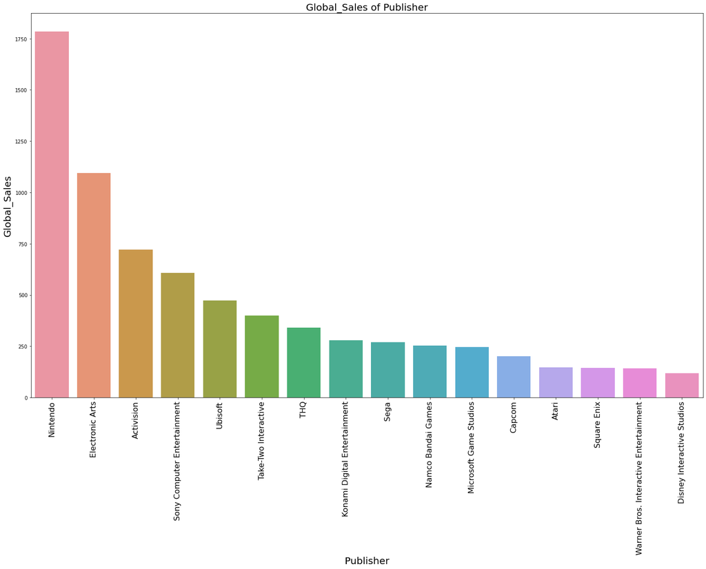

```python
publisher = df.groupby(['Publisher']).sum().loc[:,'Global_Sales'].sort_values(ascending=False)
publisher_data = publisher[publisher.values > 100]
plt.figure(figsize=(20,16))
sns.barplot(y=publisher_data.values, x=publisher_data.index)
plt.xticks(plt.xticks()[0], rotation=90, size=16)
plt.tight_layout()
plt.title('Global_Sales of Publisher', fontsize = 20)
plt.xlabel('Publisher', fontsize = 20)
plt.ylabel('Global_Sales', fontsize = 20)
plt.show()
```

由图中可以看出，受欢迎的游戏发行商前三名为：Nintendo、Electronic Arts、Activision，其中Nintendo发行的游戏最受欢迎。

# 三、预测每年电子游戏销售额

```python
df.groupby('Year').count()
```

| Year | Rank | Name | Platform | Genre | Publisher | NA_Sales | EU_Sales | JP_Sales | Other_Sales | Global_Sales |
| --- | --- | --- | --- | --- | --- | --- | --- | --- | --- | --- |
| 1980.0 | 9 | 9 | 9 | 9 | 9 | 9 | 9 | 9 | 9 | 9 |
| 1981.0 | 46 | 46 | 46 | 46 | 46 | 46 | 46 | 46 | 46 | 46 |
| 1982.0 | 36 | 36 | 36 | 36 | 36 | 36 | 36 | 36 | 36 | 36 |
| 1983.0 | 17 | 17 | 17 | 17 | 17 | 17 | 17 | 17 | 17 | 17 |
| 1984.0 | 14 | 14 | 14 | 14 | 14 | 14 | 14 | 14 | 14 | 14 |
| 1985.0 | 14 | 14 | 14 | 14 | 14 | 14 | 14 | 14 | 14 | 14 |
| 1986.0 | 21 | 21 | 21 | 21 | 21 | 21 | 21 | 21 | 21 | 21 |
| 1987.0 | 16 | 16 | 16 | 16 | 16 | 16 | 16 | 16 | 16 | 16 |
| 1988.0 | 15 | 15 | 15 | 15 | 15 | 15 | 15 | 15 | 15 | 15 |
| 1989.0 | 17 | 17 | 17 | 17 | 17 | 17 | 17 | 17 | 17 | 17 |
| 1990.0 | 16 | 16 | 16 | 16 | 16 | 16 | 16 | 16 | 16 | 16 |
| 1991.0 | 41 | 41 | 41 | 41 | 41 | 41 | 41 | 41 | 41 | 41 |
| 1992.0 | 43 | 43 | 43 | 43 | 43 | 43 | 43 | 43 | 43 | 43 |
| 1993.0 | 60 | 60 | 60 | 60 | 60 | 60 | 60 | 60 | 60 | 60 |
| 1994.0 | 121 | 121 | 121 | 121 | 121 | 121 | 121 | 121 | 121 | 121 |
| 1995.0 | 219 | 219 | 219 | 219 | 219 | 219 | 219 | 219 | 219 | 219 |
| 1996.0 | 263 | 263 | 263 | 263 | 263 | 263 | 263 | 263 | 263 | 263 |
| 1997.0 | 289 | 289 | 289 | 289 | 289 | 289 | 289 | 289 | 289 | 289 |
| 1998.0 | 379 | 379 | 379 | 379 | 379 | 379 | 379 | 379 | 379 | 379 |
| 1999.0 | 338 | 338 | 338 | 338 | 338 | 338 | 338 | 338 | 338 | 338 |
| 2000.0 | 349 | 349 | 349 | 349 | 349 | 349 | 349 | 349 | 349 | 349 |
| 2001.0 | 482 | 482 | 482 | 482 | 482 | 482 | 482 | 482 | 482 | 482 |
| 2002.0 | 829 | 829 | 829 | 829 | 829 | 829 | 829 | 829 | 829 | 829 |
| 2003.0 | 775 | 775 | 775 | 775 | 775 | 775 | 775 | 775 | 775 | 775 |
| 2004.0 | 744 | 744 | 744 | 744 | 744 | 744 | 744 | 744 | 744 | 744 |
| 2005.0 | 936 | 936 | 936 | 936 | 936 | 936 | 936 | 936 | 936 | 936 |
| 2006.0 | 1008 | 1008 | 1008 | 1008 | 1008 | 1008 | 1008 | 1008 | 1008 | 1008 |
| 2007.0 | 1201 | 1201 | 1201 | 1201 | 1201 | 1201 | 1201 | 1201 | 1201 | 1201 |
| 2008.0 | 1428 | 1428 | 1428 | 1428 | 1428 | 1428 | 1428 | 1428 | 1428 | 1428 |
| 2009.0 | 1431 | 1431 | 1431 | 1431 | 1431 | 1431 | 1431 | 1431 | 1431 | 1431 |
| 2010.0 | 1257 | 1257 | 1257 | 1257 | 1257 | 1257 | 1257 | 1257 | 1257 | 1257 |
| 2011.0 | 1136 | 1136 | 1136 | 1136 | 1136 | 1136 | 1136 | 1136 | 1136 | 1136 |
| 2012.0 | 655 | 655 | 655 | 655 | 655 | 655 | 655 | 655 | 655 | 655 |
| 2013.0 | 546 | 546 | 546 | 546 | 546 | 546 | 546 | 546 | 546 | 546 |
| 2014.0 | 580 | 580 | 580 | 580 | 580 | 580 | 580 | 580 | 580 | 580 |
| 2015.0 | 614 | 614 | 614 | 614 | 614 | 614 | 614 | 614 | 614 | 614 |
| 2016.0 | 342 | 342 | 342 | 342 | 342 | 342 | 342 | 342 | 342 | 342 |
| 2017.0 | 3 | 3 | 3 | 3 | 3 | 3 | 3 | 3 | 3 | 3 |
| 2020.0 | 1 | 1 | 1 | 1 | 1 | 1 | 1 | 1 | 1 | 1 |

由表中可以看出，2017年和2020年的数据非常少，较为异常，故删除2017年和2020年的数据。 并根据除了'Name'之外的所有特征进行预测。

```python
df = df[df.Year <= 2016]
y = df.Global_Sales
x = df.drop(['Name','Global_Sales'], axis=1)
```

对特征中非int类型的数据进行编码，并划分数据集

```python
LE = LabelEncoder()
x.Platform = LE.fit_transform(df.Platform)
x.Genre = LE.fit_transform(df.Genre)
x.Publisher = LE.fit_transform(df.Publisher)
X_train, X_test, y_train, y_test = train_test_split(x, y, test_size=0.25, random_state=2)
```

使用交叉验证进行参数调优

```python
#使用交叉验证进行参数调优
Tree = DecisionTreeRegressor(random_state=2)
param_grid = {
     'max_depth': [10, 15],
     #'min_sample_leaf': [30, 50, 100],
     'splitter': ('random', 'best')
}
grid_search = GridSearchCV(Tree, param_grid, scoring='r2', cv=10)
grid_search.fit(X_train, y_train)
print('训练集best_score_: ' + str(grid_search.best_score_))
print('测试集score: ' + str(grid_search.score(X_test, y_test)))  # 分数
print(grid_search.best_params_)  # 最好的超参数
print(grid_search.best_estimator_) #决策树的参数设置
```

```
训练集best_score_: 0.9925955193173556
测试集score: 0.879772360102238
{'max_depth': 15, 'splitter': 'random'}
DecisionTreeRegressor(max_depth=15, random_state=2, splitter='random')
```

可以发现，决策树最大深度为15、特征划分点选择标准为random时，效果更好，所以使用这一组参数进行训练并预测。

```python
#使用调好的参数训练并预测
model = grid_search.best_estimator_.fit(X_train, y_train)
y_pred = model.predict(X_test)
print(y_pred)

print('mean_squared_error:', mean_squared_error(y_test, y_pred))
print('r2_score:', r2_score(y_test, y_pred))
```

```
[0.04 0.02 0.13 ... 9.02 0.07 0.05]
mean_squared_error: 0.4585997438798242
r2_score: 0.879772360102238
```

可以发现，预测值与实际值之差平方的期望值为0.458，r2_score为为0.880。

# 四、可视化应用：展示销售故事

## 1、游戏在不同地区的销量分布

```
0.4910986957010223 0.2731265384497533 0.23577476584922435
```

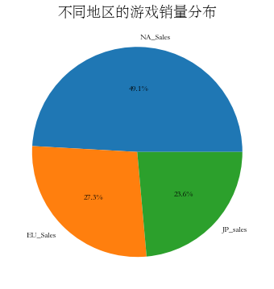

```python
plt.rcParams['font.sans-serif']=['STSong']
plt.rcParams['axes.unicode_minus'] = False
sales_table = df.pivot_table(index='Name',values=['NA_Sales','EU_Sales','JP_Sales','Global_Sales'],aggfunc=np.sum)
property_NA = sales_table['NA_Sales'].sum()/sales_table['Global_Sales'].sum()
property_EU = sales_table['EU_Sales'].sum()/sales_table['Global_Sales'].sum()
property_JP = 1 - property_EU - property_NA
#property_JP = sales_table['JP_Sales'].sum()/sales_table['Global_Sales'].sum()
properties = (property_NA,property_EU,property_JP)
property_label = ('NA_Sales','EU_Sales','JP_sales')
print(property_NA,property_EU,property_JP)
plt.figure(figsize = (6,6))
plt.title("不同地区的游戏销量分布", fontsize=18)
plt.pie(x=properties, labels=property_label, autopct="%0.1f%%", shadow=False)
plt.show()
```

## 2、各个地区的游戏类型销量占比

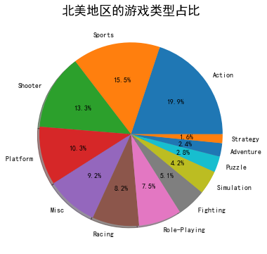

```python
Genre_NA = df.groupby(['Genre']).sum().loc[:,'NA_Sales'].sort_values(ascending=False)
Genre_EU = df.groupby(['Genre']).sum().loc[:,'EU_Sales'].sort_values(ascending=False)
Genre_JP = df.groupby(['Genre']).sum().loc[:,'JP_Sales'].sort_values(ascending=False)
Genre_NA = Genre_NA[Genre_NA.values > 60]
Genre_EU = Genre_EU[Genre_EU.values > 60]
Genre_JP = Genre_JP[Genre_JP.values > 60]
label_NA = Genre_NA._stat_axis.values.tolist()
label_EU = Genre_EU._stat_axis.values.tolist()
label_JP = Genre_JP._stat_axis.values.tolist()
plt.rcParams['font.sans-serif']=['SimHei']
plt.rcParams['axes.unicode_minus'] = False
plt.figure(figsize = (6,6))
plt.title("北美地区的游戏类型占比", fontsize=18)
plt.pie(x = Genre_NA,labels = label_NA,autopct = "%0.1f%%",shadow = True)
plt.show()
```

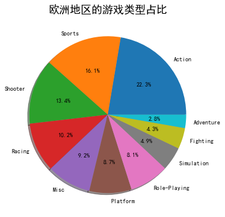

```python
plt.figure(figsize = (6,6))
plt.title("欧洲地区的游戏类型占比", fontsize=18)
plt.pie(x = Genre_EU,labels = label_EU,autopct = "%0.1f%%",shadow = True)
plt.show()
```

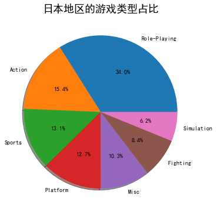

```python
plt.figure(figsize = (6,6))
plt.title("日本地区的游戏类型占比", fontsize=18)
plt.pie(x = Genre_JP,labels = label_JP,autopct = "%0.1f%%",shadow = True)
plt.show()
```

由三个地区的游戏类型占比饼状图可以看出：  
(1)在北美地区市场，大家更钟情于动作、运动、设计类型的游戏，而北美又作为国际的主要市场，在推出新游戏时应当着重考虑这三种类型。  
(2)在欧洲地区市场，销售量排名较前的游戏类型和北美地区较为相似，也是动作类游戏的受众群体更大。  
(3)在日本地区市场，销售的趋势则与北美和欧洲截然不同，角色扮演类游戏在日本占了三分之一的销售比重，可见日本更热爱角色扮演类游戏，所以在推出游戏时应着重考虑这一类型。  
总体来说，在三个地区的市场中，动作和运动类型的销量始终比较稳定，稳居前三。

## 3、游戏类型销量随时间的变化趋势

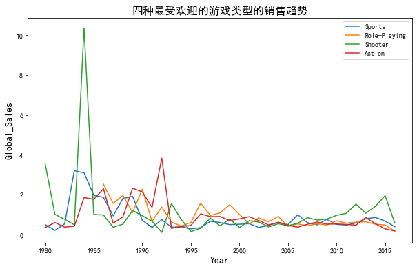

```python
genre_tend = df.groupby(['Genre'])['Global_Sales'].sum().sort_values(ascending=False).head(4).index
genre_tend = df[df.Genre.isin(genre_tend)]
plt.figure(figsize = (10,6))
sns.lineplot(x='Year', y='Global_Sales', hue='Genre', data=genre_tend, ci=None)
plt.legend(loc='upper right')
plt.xlabel('Year', fontsize=14)
plt.ylabel('Global_Sales', fontsize=14)
plt.title('四种最受欢迎的游戏类型的销售趋势', fontsize=16)
plt.show()
```

由图中可以发现：在四种销量最高的游戏类型中，射击类型的游戏曾在1985年左右创造了历史销量最高纪录，但在随后的20年中销量下滑，从2010年起又超越了其他类型的游戏。其他三种类型的游戏在1995年以前每年的销量也有波动，但自2000年之后这些类型的游戏销量也都趋于平稳。